# RNA-seq tutorial

Mark Dunning

# Hands-on RNA-seq Analysis from fastq

### Sheffield Bioinformatics Core

web : sbc.shef.ac.uk  
twitter: [@SheffBioinfCore](https://twitter.com/SheffBioinfCore)  
email: bioinformatics-core@sheffield.ac.uk

## Tutorial Overview

This tutorial will cover the basics of RNA-seq using Galaxy and Degust; two open-source web-based platforms for the analysis of biological data. You should gain an appreciation of the tasks involved in a typical RNA-seq analysis and be comfortable with the outputs generated by the Bioinformatician.

## Using these notes

Sections with this background indicate exercises to be completed during the workshop.

Sections with this background highlight particular shortcuts or other references that might be useful.

Sections with this background give information about potential error messages or might encounter, or problems that might arise in your own data analysis.

### More on Galaxy

The official Galaxy page has many [tutorials](https://galaxyproject.org/learn/) on using the service, and examples of other types of analysis that can be performed on the platform.

Those eventually wanted to perform their own RNA-seq analysis (for example in R), should look out for other courses

### Courses on analysing RNA-seq data in R

- [Sheffield Bioinformatics Core](https://sbc.shef.ac.uk/training/rna-seq-in-r-2020-02-13/)
- [Monash Bioinformatics Platform](http://monashbioinformaticsplatform.github.io/RNAseq-DE-analysis-with-R/)

## RNA-seq workflow

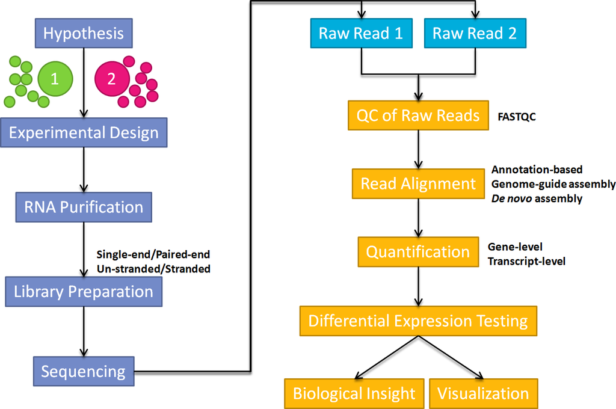

Workflow image from Ting-you Wang’s [RNA-seq data analysis page](https://databeauty.com/blog/tutorial/2016/09/13/RNA-seq-analysis.html)

## Background

#### Where do the data in this tutorial come from?

The data for this tutorial comes from a Journal of Experimental Medicine paper [“Itraconazole targets cell cycle heterogeneity in colorectal cancer”](https://pubmed.ncbi.nlm.nih.gov/29853607/). This study examines the expression profiles of two cell lines in response to treatment with itraconazole.

For this tutorial, we will assume that the *wet-lab* stages of the experiment have been performed and we are now in the right-hand branch of the workflow. In this tutorial we will demonstrate the steps of **Quality assessment**, **alignment**, **quantification** and **differential expression testing**.

The *summarised* data for this experiment were made available on the Sequencing Read Archive with accession SRP144496. **For the purposes of this workshop we have created a downsampled dataset**

If you want to know how to obtain these data, see the optional Appendix

## Section 1: Preparation

#### 1. Sign-up to the European Galaxy server

- https://usegalaxy.eu
- The Australian server is an alternative if the European one is down:- https://usegalaxy.org.au/

**Make sure you check your email to activate your account**

#### 2. Download the course data

The data for this course have all been shared on a google drive. If you have not done so already, please download this directory as a zip file

https://drive.google.com/open?id=1ftuBP5L-rcXwsEub2mIaSDJ1tceHYFc7

[figure not shown]

#### 3. Import the RNA-seq data for the workshop.

We can going to import the [*fastq* files](https://en.wikipedia.org/wiki/FASTQ_format) for this experiment. This is a standard format for storing raw sequencing reads and their associated quality scores. To make the practical quicker, we have *downsampled* the original fastq files to a quarter of a million reads.

| run | name | cell_line | condition |
| --- | --- | --- | --- |
| SRR7108388 | HT55_CONT_1 | HT55 | DMSO |
| SRR7108389 | HT55_CONT_2 | HT55 | DMSO |
| SRR7108390 | HT55_CONT_3 | HT55 | DMSO |
| SRR7108391 | HT55_CONT_4 | HT55 | DMSO |
| SRR7108392 | HT55_ITRA_1 | HT55 | ITRACONAZOLE |
| SRR7108393 | HT55_ITRA_2 | HT55 | ITRACONAZOLE |
| SRR7108394 | HT55_ITRA_3 | HT55 | ITRACONAZOLE |
| SRR7108395 | HT55_ITRA_4 | HT55 | ITRACONAZOLE |
| SRR7108396 | SW948_CONT_1 | SW948 | DMSO |
| SRR7108397 | SW948_CONT_2 | SW948 | DMSO |
| SRR7108398 | SW948_CONT_3 | SW948 | DMSO |
| SRR7108399 | SW948_CONT_4 | SW948 | DMSO |
| SRR7108400 | SW948_ITRA_1 | SW948 | ITRACONAZOLE |
| SRR7108401 | SW948_ITRA_2 | SW948 | ITRACONAZOLE |
| SRR7108402 | SW948_ITRA_3 | SW948 | ITRACONAZOLE |
| SRR7108403 | SW948_ITRA_4 | SW948 | ITRACONAZOLE |

#### **Get Data -> Upload File**

You can import the data by:

1. In the tool panel located on the left, under Basic Tools select **Get Data > Upload File**. Click on the **Choose local file** button on the bottom section of the pop-up window.
2. Navigate to the `fastq` directory of the zip file that you downloaded from google drive and select these two filesfrom the HT55-DMSO condition.

`SRR7108388.fastq.gz` `SRR7108389.fastq.gz`

and these two files are from the HT55 ITRACONAZOLE condition.

`SRR7108392.fastq.gz` `SRR7108393.fastq.gz`

3. You should now have these 4 files in your history:
   - `SRR7108388.fastq.gz`
   - `SRR7108389.fastq.gz`
   - `SRR7108392.fastq.gz`
   - `SRR7108393.fastq.gz`

The `.gz` at the end of each file name means that it is *compressed* (like a zip file).

### Quality assessment with FastQC (Optional)

[FastQC](https://www.bioinformatics.babraham.ac.uk/projects/fastqc/) is a popular tool from [Babraham Institute Bioinformatics Group](https://www.bioinformatics.babraham.ac.uk/index.html) used for *quality assessment* of sequencing data. Most Bioinformatics pipelines will use FastQC, or similar tools in the first stage of the analysis. The [documentation](https://www.bioinformatics.babraham.ac.uk/projects/fastqc/Help/) for FastQC will help you to interpret the plots and stats produced by the tool. A traffic light system is used to alert the user’s attention to possible issues. However, it is worth bearing in mind that the tool is blind to the particular type of sequencing you are performing (i.e. whole-genome, ChIP-seq, RNA-seq), so some warnings might be expected due to the nature of your experiment.

#### *FastQ Quality Control* -> *FastQC Read Quality reports*

**Make sure you select this tool. There is another version of FastQC present, which does not produce some of the output we need for a later step**

- Select one of the FASTQ files as input and *Execute* the tool.
- When the tool finishes running, you should have an HTML file in your History. Click on the eye icon to view the various quality metrics.
- Run Fastqc on the remaing fastq files, but don’t examine the results just yet.

**Question: Do the data seem to be of reasonable quality?**

You can use the [documentation](https://www.bioinformatics.babraham.ac.uk/projects/fastqc/Help/3%20Analysis%20Modules/) to help interpret the plots

If poor quality reads towards the ends of reads are considered to be a problem, or there is considerable adapter contamination, we can employ various tools to *trim* our data.

However, a recent paper demonstrated that read trimming is no longer required prior to alignment:- https://www.biorxiv.org/content/10.1101/833962v1

If you suspect contamination from adapter sequence or unacceptable quality scores towards the ends of reads various trimming options are supported by the *Trimmomatic* tool (amongst others)

#### *FASTA/FASTQ* -> *Trimmomatic*

The operations supported by trimmomatic will probably not be very informative on our example data (as it has already been processed), but you can try several operations if you get time:-

- Removing Illumina adapter sequences by setting *Perform initial ILLUMINACLIP* to *Yes* and selecting the appropriate adapter type
- Remove poor quality bases at the end of reads by choosing *Cut bases off the end of a read, if below a threshold quality (TRAILING)* under *Select Trimmomatic operation to perform*
- Remove poor quality bases at the start of reads by choosing *Cut bases off the start of a read, if below a threshold quality (LEADING)* under *Select Trimmomatic operation to perform*
- You can apply multiple operations in turn by clicking *Insert Trimmomatic Operation*

If you also suspect contamination by another organism, or rRNA present in your data, you can use the sortMeRNA tool to remove this artefact.

### Combining QC reports

It can be quite tiresome to click through multiple QC reports and compare the results for different samples. It is useful to have all the QC plots on the same page so that we can more easily spot trends in the data.

The [multiqc](https://multiqc.info/) tool has been designed for the tasks of aggregating qc reports and combining into a single report that is easy to digest.

*FASTQ Quality Control* -> *Multiqc*

Under *Which tool was used generate logs?* Choose *fastqc* and select the RawData output from the fastqc run on each of your bam files.

Question: Repeat the FastQC analysis for the remaining fastq files and combine the reports with `multiQC`. Do the fastq files seem to have consistently high-quality?

## Section 2: Quantification

We can align our RNA-seq reads to a reference *genome*, and then overlap with know gene coordinates, but many prefer to align directly to the *transcriptome* sequences using a method such as salmon or kallisto. We will demonstrate the salmon protocol.

### Obtaining the files for salmon

1. cDNA fasta file

This can be obtained from [Ensembl](http://m.ensembl.org/info/data/ftp/index.html)

2. Transcript mapping file

By default, salmon will produce counts for each *transcript*. This might be what we want, but for most standard analyses it is preferable to work at the gene-level. We therefore have to tell salmon how the transcripts in the cDNA file relate to known genes. Such a file can be obtained from [biomart](https://ensembl.org/biomart/martview/).

- Select the Ensembl genes (104) database
- Select the dataset Human genes (GRCh38.13)
- In Attributes, click the “+” button next to GENE and select *Transcript stable ID version* and *Gene stable ID*. Make sure the order on the left-hand panel is *Transcript stable ID version*, followed by *Gene stable ID*. This will affect the column order in the file. You can tick / untick the IDs to make sure the order is correct.

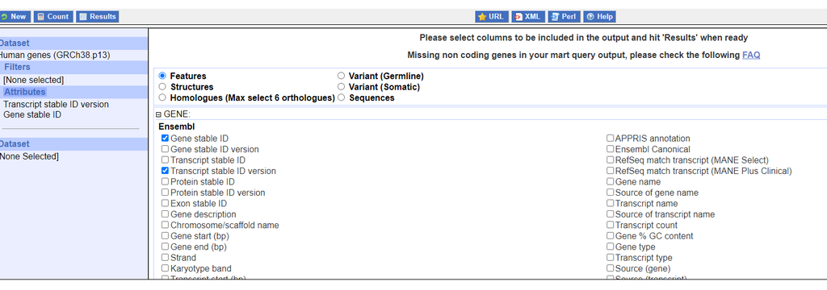

- Click the Results button in the top left corner to see a preview of the results. Clicking the Go button will export the results to a file

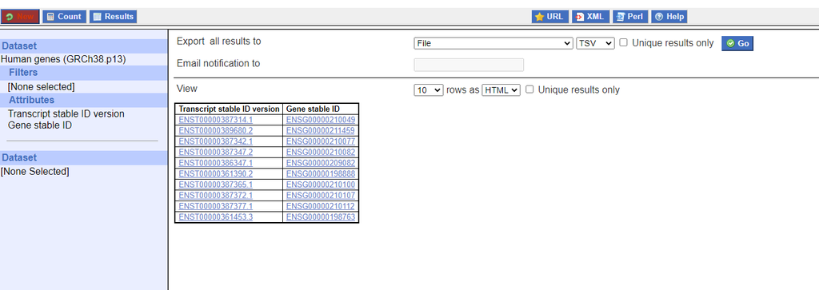

**It is important that the file downloaded from Biomart is edited so that the column headings do not contain any spaces**. You can do this in a text editor. The edited file should look like this.

[figure not shown]

It is important to make sure the version number of your transcript file and the biomaRt dataset are **the same**, otherwise some of the steps downstream might not work as expected.

3. Annotation file (optional)

The Ensembl gene IDs are not particularly memorable, so it would be highly beneficial to have other annotations at hand to help us interpret the data downstream. We can use the biomart website again to produce a table to downstream intrepretation.

This time, select only the *Gene Stable ID* tickbox in the GENE box. Expand the EXTERNAL panel by clicking the “+” next to EXTERNAL, and select *HGNC symbol* and *NCBI gene (formerly Entrezgene) ID*

### salmon configuration and running

**RNA Analysis** -> **Salmon quant**

- Select the *Homo_sapiens_GRCh38.cdna.all.fa.gz* file as the Transcripts fasta file
- Select all your uploaded fastq files as your Data Input FASTQ/FASTA file
- Scroll down *File containing a mapping of transcripts to genes* and select the *mart_export.txt* file

Two jobs will now be queued for each sample fastq file. The Quantification output will contain transcript-level data, and the Gene Quantification output will be at the *gene-level*. We should expect the number of lines in the Gene Quantification file to be substantially less. If not, you will need to check that your transcript mapping file was correct.

The Gene Quantification output from each sample comprises the following columns:-

- Name; The Ensembl Gene ID (Gene Stable ID from biomart)
- Length;
- Effective Length;
- TPM; Transcripts Per Million
- NumReads; The raw number of reads

Note that we are using a downsampled dataset, so the majority of NumReads will be zero.

### Create a count matrix

Methods for detecting differential expression are likely to want data in the form of a table; where every row is a different gene and each column is a unique biological sample. Before we can proceed we will therefore need to *merge* our salmon results into a single output. This can be down using the *Salmon quantmerge* tool

**RNA Analysis** -> **Salmon quantmerge**

Use the +Insert Quant file and names button repeatedly to select each of your *Gene Quantification* outputs. The One-word sample names text box can be used to create a shorter column name for each output.

Once all the Gene Quantification files have been selected the drop-down menu under **Columns** should be changed from Length to NumReads.

### Adding extra annotation to results

**Text Manipulation** -> **Join two files**

## Differential Expression using Degust

Differential expression is possible using Galaxy using the DESeq2 tool (for example). However, our particular recommendation is to use Degust for a more interactive experience. For this section, we will be using counts generated on the full dataset, rather than the downsampled data analysed in the previous section. These counts are available in the file `GSE114013_salmon_counts.csv`.

## Differential expression

The term *differential expression* was first used to refer to the process of finding statistically significant genes from a *microarray* gene expression study.

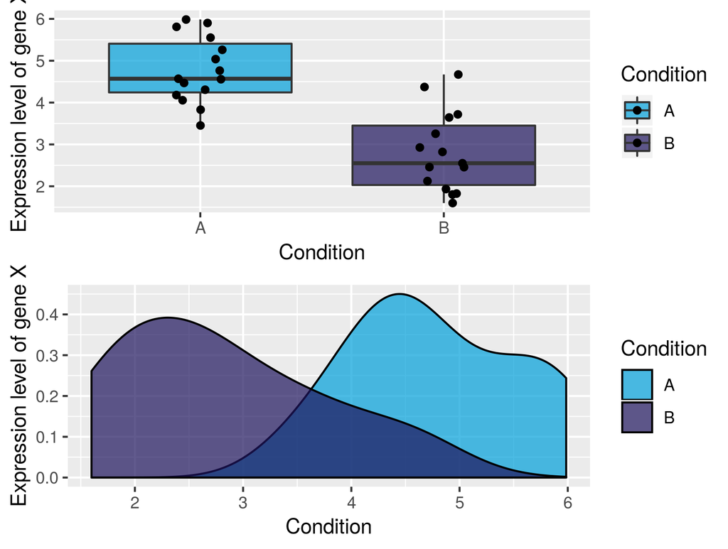

Such methods were developed on the premise that microarray expression values are approximately *normally-distributed* when appropriately transformed (e.g. by using a log$_2$ transformation) so that a modified version of the standard *t-test* can be used. The same test is applied to each gene under investigation yielding a *test statistic*, *fold-change* and *p-value*. Similar methods have been adapted to RNA-seq data to account for the fact that the data are *count-based* and do not follow a normal distribution.

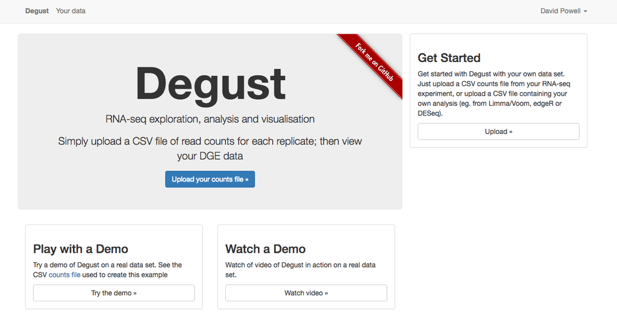

http://degust.erc.monash.edu/

`Degust` is a web tool that can analyse the counts files produced in the step above, to test for differential gene expression. It offers and interactive view of the differential expression results

The input file is a count matrix where each row is a measured gene, and each column is a different biological sample. Within the tool we can configure which samples belong to the different biological groups of interest.

Read counts have to be normalised first prior to differential expression testing. There are two main biases that need to be accounted for:-

- size of gene
  - *longer* genes will have more reads assigned to them
- library size
  - a sample that is sequenced to a higher depth will receive more reads

However, R-based methods such as `edgeR` (implemented in Degust) and `DESeq2` have their own method of normalising counts. You will probably encounter other methods of normalising RNA-seq reads such as *RPKM*, *CPM*, *TPM* etc. [This blog](https://www.rna-seqblog.com/rpkm-fpkm-and-tpm-clearly-explained/) provides a nice explanation of the current thinking. As part of the `Degust` output, you have the option of downloading normalised counts in various formats. Some other online visualisation tools require normalised counts as input, so it is good to have these to-hand.

### Uploading the count matrix to Degust

- From the main degust page, click *Upload your counts file*
- Click on Browse
- Select the location of the file `GSE114013_salmon_counts.csv`, and click *Open*.
- Click *Upload*
- A Configuration page will appear.

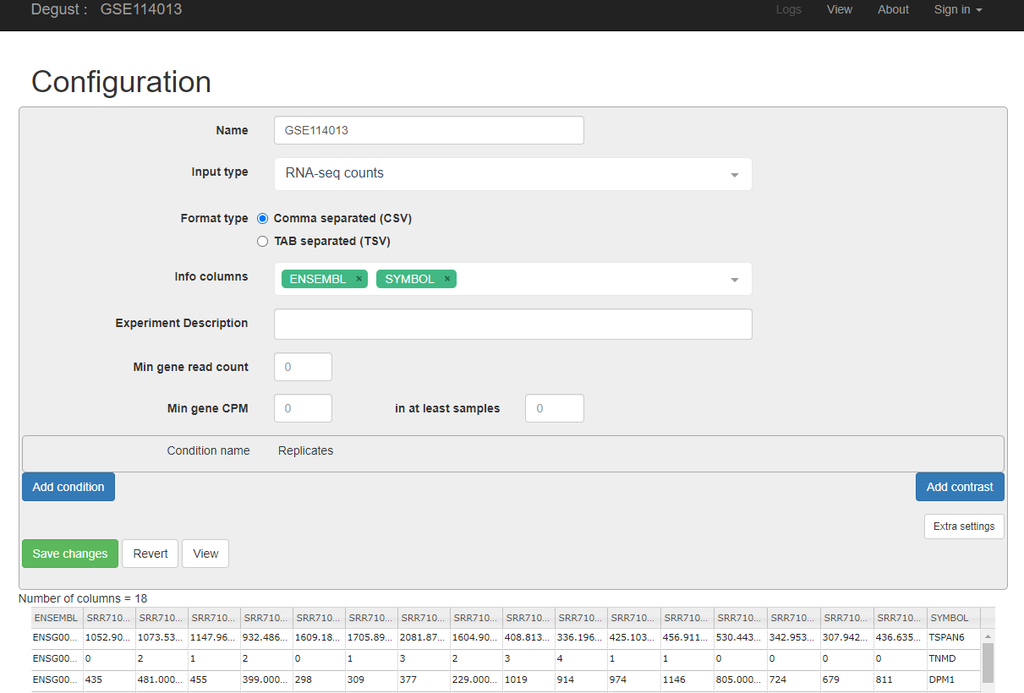

- For Name type “*GSE114013*” (or whatever you want to call the analysis)
- For Info columns select *SYMBOL*
- Click Add condition
  - Referring to the experiment design (below), select the DMSO samples and call the condition DMSO
  - Repeat for the ITRACONAZOLE samples
- Save the settings and then View the results

| run | name | cell_line | condition |
| --- | --- | --- | --- |
| SRR7108388 | HT55_CONT_1 | HT55 | DMSO |
| SRR7108389 | HT55_CONT_2 | HT55 | DMSO |
| SRR7108390 | HT55_CONT_3 | HT55 | DMSO |
| SRR7108391 | HT55_CONT_4 | HT55 | DMSO |
| SRR7108392 | HT55_ITRA_1 | HT55 | ITRACONAZOLE |
| SRR7108393 | HT55_ITRA_2 | HT55 | ITRACONAZOLE |
| SRR7108394 | HT55_ITRA_3 | HT55 | ITRACONAZOLE |
| SRR7108395 | HT55_ITRA_4 | HT55 | ITRACONAZOLE |
| SRR7108396 | SW948_CONT_1 | SW948 | DMSO |
| SRR7108397 | SW948_CONT_2 | SW948 | DMSO |
| SRR7108398 | SW948_CONT_3 | SW948 | DMSO |
| SRR7108399 | SW948_CONT_4 | SW948 | DMSO |
| SRR7108400 | SW948_ITRA_1 | SW948 | ITRACONAZOLE |
| SRR7108401 | SW948_ITRA_2 | SW948 | ITRACONAZOLE |
| SRR7108402 | SW948_ITRA_3 | SW948 | ITRACONAZOLE |
| SRR7108403 | SW948_ITRA_4 | SW948 | ITRACONAZOLE |

### Overview of Degust sections

- Top black panel with Configure settings at right.
- Left: Conditions: DMSO and ITRACONAZOLE.
- Top centre: Plots, with options at right.
- When either of the expression plots are selected, a heatmap appears below.
- A table of genes (or features); expression in treatment relative to control (Treatment column); and significance (FDR column).

(**Not that the screenshots are for illustration purposes and taken from a different dataset to that being analysed in the tutorial**)

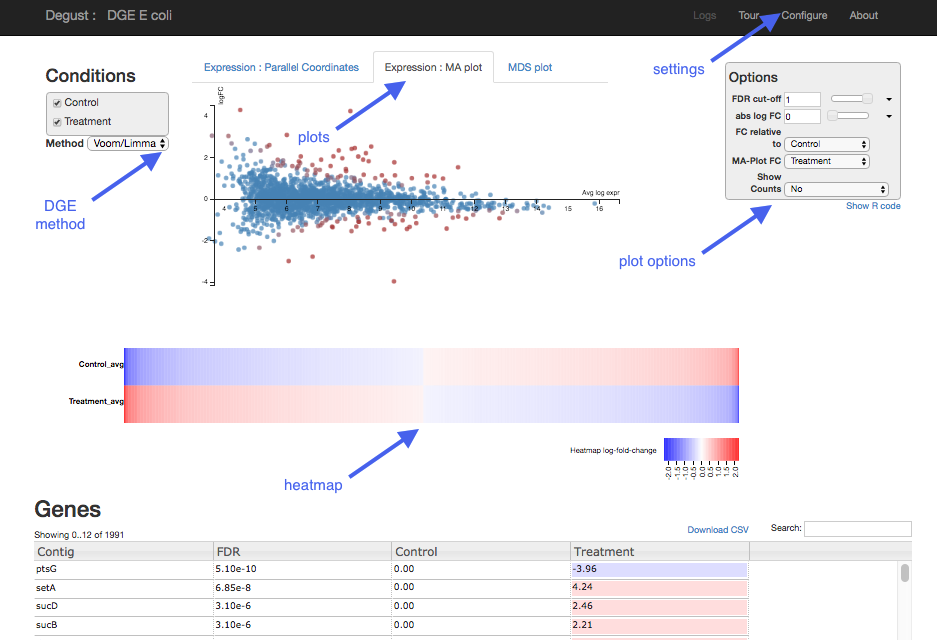

### MA-plot

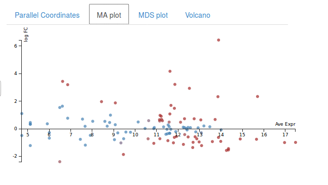

Each dot shows the change in expression in one gene.

- The average expression (over both condition and treatment samples) is represented on the x-axis.
  - Plot points should be symmetrical around the x-axis.
  - We can see that many genes are expressed at a low level, and some are highly expressed.
- The fold change is represented on the y axis.
  - If expression is significantly different between batch and chem, the dots are red. If not, they are blue. (In Degust, significant means FDR <0.05).
  - At low levels of gene expression (low values of the x axis), fold changes are less likely to be significant.

Click on the dot to see the gene name.

### Parallel coordinates and heatmap

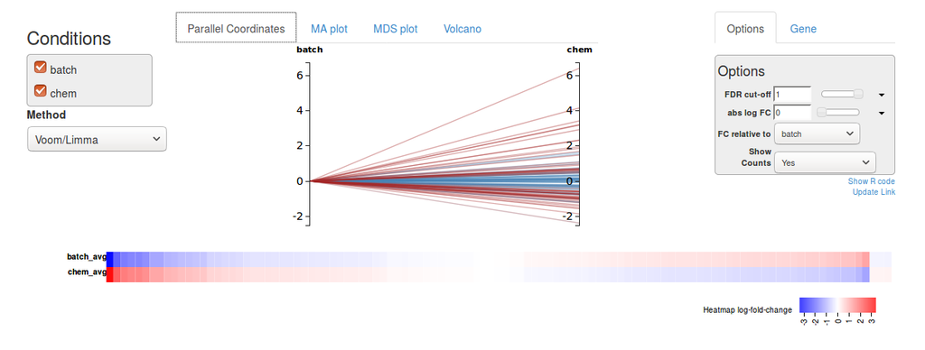

Each line shows the change in expression in one gene, between control and treatment.

- Go to Options at the right.
  - For FDR cut-off set at 0.001.
  - This is a significance level (an adjusted p value). We will set it quite low in this example, to ensure we only examine key differences.
- Look at the Parallel Coordinates plot. There are two axes:
  - Left: Control: Gene expression in the control samples. All values are set at zero.
  - Right: Treatment Gene expression in the treatment samples, relative to expression in the control.
- The blocks of blue and red underneath the plot are called a heatmap.
  - Each block is a gene. Click on a block to see its line in the plot above.
  - Look at the row for the chem. Relative to batch, genes expressed more are red; genes expressed less are blue.

### Table of genes

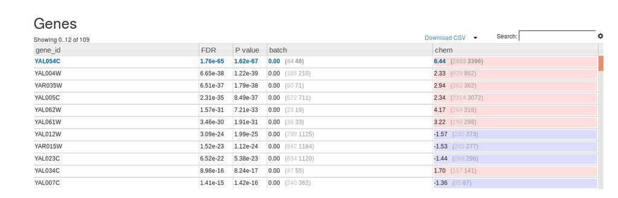

Table of genes

The table can be sorted according to any of the columns (e.g. fold-change or p-value)

### Download and R code

Above the genes table is the option to download the results of the current analysis to a csv file. You can also download the *R* code required to reproduce the analysis by clicking the *Show R code* box underneath the Options box.

Plots such as the MDS, MA and heatmap can also be exported by right-clicking on the plot.

### MDS plot

This is a multidimensional scaling plot which represents the variation between samples. It is a similar concept to a Principal Components Analysis (PCA) plot. The x-axis is the dimension with the highest magnitude. In a standard control/treatment setup, samples should be split along this axis. A desirable plot is shown below:-

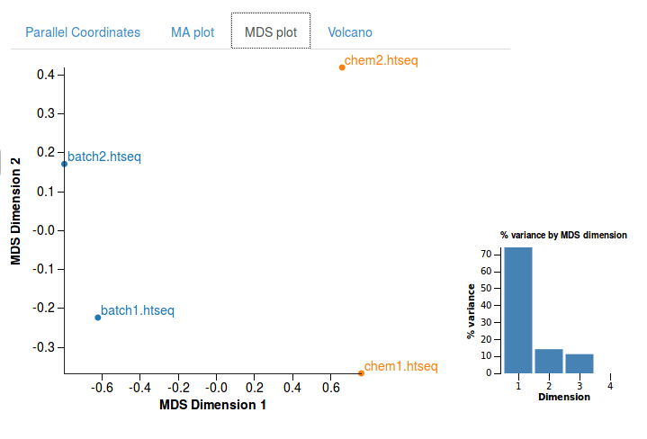

### Exercise

**Question:** It seems that the differential expression analysis is detecting lots of genes. However, does this tell the whole story about the dataset? What do you think is the main factor separating samples on the x-axis, and thus explaning the most variation in the data?

## Modifying the analysis

We will now repeat the analysis, but only for samples from the *HT55* cell-line. The correct configuration for this analysis is shown below:-

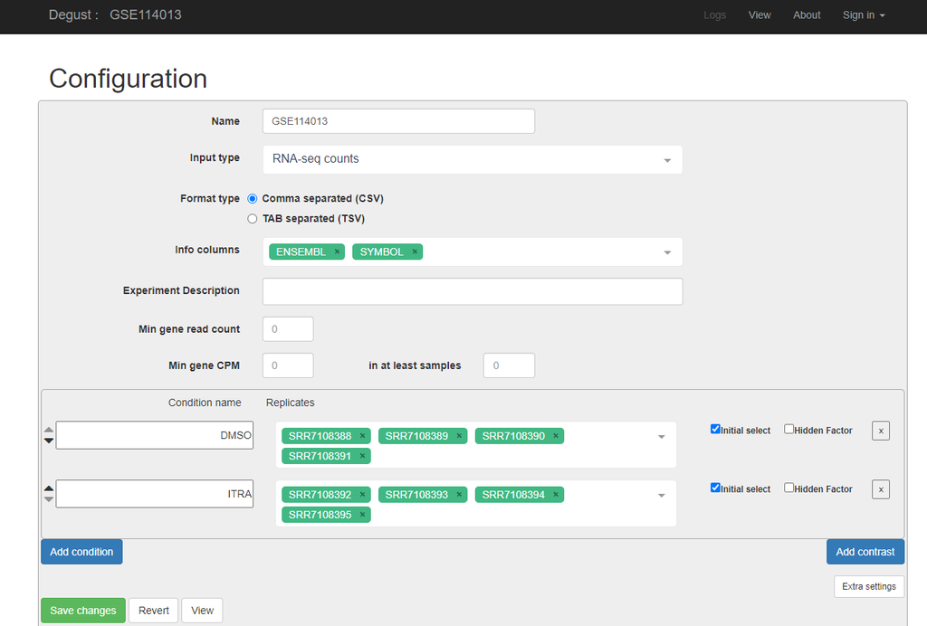

**Exercise**: How many genes are differentially-expressed with an FDR < 0.05 and abs logFC > 1. Download this file and rename it to `HT55.ITRACONAZOLE_vs_DMSO.csv`.

**Exercise**: Repeat the analysis for SW948 samples and download the table of differentially-expressed results (same FDR and log fold-change) to `SW948.ITRACONAZOLE_vs_DMSO.csv`

**Exercise:** Rest the FDR cut-off and abs LogFC cutoffs back to default and *download* the file and rename to `background.csv`. We will use this later.

### File Downloads

If you didn’t manage to complete these analyses, you can download the files from here by right-clicking on each link and selecting “Save Link as” (or equivalent). They are also available in the course google drive.

- HT55.ITRACONAZOLE_vs_DMSO.csv
- SW948.ITRACONAZOLE_vs_DMSO.csv
- background.csv

### Overlapping Gene Lists

[figure not shown]

We might sometimes want to compare the lists of genes that we identify using different methods, or genes identified from more than one contrast. In our example dataset we can compare the genes in the contrast of ITRACONAZOLE vs DMSO in HT55 and SW948 cells

The website *venny* provides a really nice interface for doing this.

[figure not shown]

- Open both your *HT55: ITRACONAZOLE vs DMSO* and *SW948: ITRACONAZOLE vs DMSO* results files in Excel
- Go to the venny website
  - http://bioinfogp.cnb.csic.es/tools/venny/
- Copy the names of genes with adjusted p-value less than 0.05 in the HT55 analysis into the **List 1** box on the venny website. **List 1** can be renamed to *HT55*
  - *You can select all entries in a column with the shortcut CTRL + SPACE*
- Copy the names of genes with adjusted p-value less than 0.05 in the SW948 analysis into the **List 2** box on the venny website. **List 2** can be renamed to **SW948**
- venny should now report the number of genes found in each list, the size of the intersection, and genes unique to each method

### Refined analysis

The final analysis we will perform is to include all the samples, but correct for the differences in cell-line. This is achieved by telling Degust about the *hidden factors* in our dataset.

You are now ready to complete the final section on annotation and enrichment analysis